# Zadanie 3

Notatki

For optimal performance, clustering algorithms, require the data to be normalized so that no particular variable or subset of variables dominates the analysis we can use either min–max normalization or Z-score standardization

Przydział “p10.csv”, “f10.csv”, “zoo.csv”

Pierwsza czesc zadania wykonana w google sheets https://docs.google.com/spreadsheets/d/1Ooh5SHc5l4BHsASnDDOGtCxZlpGAvBzUJk6yba5RiTY/edit?usp=sharing

```r
library(tidyverse)
f10 <- read_csv("ex3students/f10.csv", col_names=FALSE )
zoo <- read_csv("ex3students/zoo.csv")
```

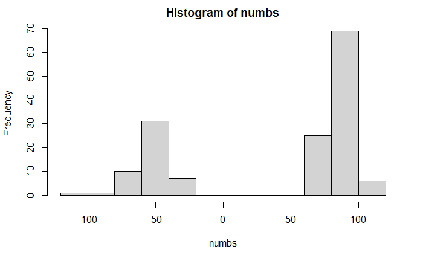

```r
numbs <- flatten_dbl(map(f10$X1, parse_number))
hist(numbs)
```

```r
km<-kmeans(numbs,2, iter.max = 20)
```

Cluster means: [,1] 1 -52.60683 2 87.60226

(between_SS / total_SS = 97.4 %)

Plik “zoo.csv” zawiera zmienne opisujące 7 typów zwierząt: ssaki, ryby, ptaki, bezkręgowce, owady, płazy i gady. Wyznaczyć grupy w zbiorze danych “zoo.csv” używając algorytmu kśrednich. Porównać otrzymane wyniki ze znaną klasyfikacją dostępną w pliku “zoo_full.xlsx” (w ostatniej kolumnie “type”). Które typy zwierząt były najczęściej mylone?

```r
kmeans(zoo, centers = 7)
```

```
K-means clustering with 7 clusters of sizes 7, 31, 8, 12, 6, 14, 23

Cluster means:
        hair feathers       eggs      milk  airborne    aquatic  predator   toothed backbone  breathes venomous      fins     legs       tail   domestic    catsize
1 1.00000000        0 0.00000000 1.0000000 0.2857143 0.14285714 0.2857143 1.0000000 1.000000 1.0000000 0.000000 0.1428571 2.000000 0.71428571 0.14285714 0.57142857
2 1.00000000        0 0.03225806 1.0000000 0.0000000 0.06451613 0.5483871 0.9677419 1.000000 1.0000000 0.000000 0.0000000 4.000000 0.90322581 0.22580645 0.80645161
3 0.00000000        0 1.00000000 0.0000000 0.0000000 0.75000000 0.7500000 0.6250000 0.750000 0.7500000 0.125000 0.0000000 4.125000 0.37500000 0.00000000 0.12500000
4 0.33333333        0 0.91666667 0.0000000 0.5000000 0.25000000 0.4166667 0.0000000 0.000000 0.7500000 0.250000 0.0000000 6.333333 0.08333333 0.08333333 0.08333333
5 0.00000000        1 1.00000000 0.0000000 0.8333333 1.00000000 0.6666667 0.0000000 1.000000 1.0000000 0.000000 0.0000000 2.000000 1.00000000 0.00000000 0.33333333
6 0.00000000        1 1.00000000 0.0000000 0.7857143 0.00000000 0.3571429 0.0000000 1.000000 1.0000000 0.000000 0.0000000 2.000000 1.00000000 0.21428571 0.28571429
7 0.04347826        0 0.82608696 0.1304348 0.0000000 0.78260870 0.7391304 0.8260870 0.826087 0.3043478 0.173913 0.6956522 0.000000 0.78260870 0.04347826 0.30434783

Clustering vector:
  [1] 2 2 7 2 2 2 2 7 7 2 2 6 7 7 3 4 6 2 7 7 6 5 2 6 4 3 3 1 2 1 4 2 1 5 7 2 2 6 7 4 4 6 4 6 2 2 4 2 2 2 2 4 3 4 2 2 6 6 5 6 7 7 7 2 2 2 7 2 2 2 2 6 4 7 7 1 7 7 5 5 7 7 7 6 1 3 7 5 4 3 3 3 7 1 2 6 1 4 2 7
[101] 6

Within cluster sum of squares by cluster:
[1]  8.571429 24.451613 12.375000 25.666667  3.500000 10.785714 44.608696
 (between_SS / total_SS =  81.5 %)

Available components:

[1] "cluster"      "centers"      "totss"        "withinss"     "tot.withinss" "betweenss"    "size"         "iter"         "ifault"
```

Przeprowadzono ręczną analize pokazaną https://docs.google.com/spreadsheets/d/1HvvOR3xo5mwljiULf23ch3WIkJ8xcOlekf4rnxsNtbU/edit?usp=sharing i najczęstsze błędy są w klasie invertebrae